# DATA SCIENCE SESSIONS VOL. 3

### A Foundational Python Data Science Course

## Task List 02: Pandas

[← Back to course webpage](https://datakolektiv.com/)

Feedback should be send to goran.milovanovic@datakolektiv.com.

These notebooks accompany the DATA SCIENCE SESSIONS VOL. 3 :: A Foundational Python Data Science Course.

[figure not shown]

### Lecturers

[Goran S. Milovanović, PhD, DataKolektiv, Chief Scientist & Owner](https://www.linkedin.com/in/gmilovanovic/)

[Aleksandar Cvetković, PhD, DataKolektiv, Consultant](https://www.linkedin.com/in/alegzndr/)

[Ilija Lazarević, MA, DataKolektiv, Consultant](https://www.linkedin.com/in/ilijalazarevic/)

### Intro

In this tasklist you'll get to exercise data frame basics on a real-world dataset. Along with this tasklist, you'll be provided with the `MovieRatings.csv` dataset, which will be stored in your `session02/_data` folder, and load it from there. The provided dataset is quite straightforward - it contains a list of movies along with their ratings from various websites.

But, before we start exploring this dataset, let's create few our small custom-made data frames:)

**00.** Import `pandas` and `os` modules.

```python
import pandas as pd
import os
```

**01.** Using a dictionary create a data frame containing five rows and three columns. Then, using `.drop()` method drop the middle column.

```python
data_dict = {'Knjiga':['Duga Gravitacije', 'Fukoovo Klatno', 'Uliks', 'Kako Upokojiti Vampira', 'Proljeća Ivana Galeba'],
            'Autor':['Tomas Pinčon', 'Umberto Eko', 'Džejms Džojs', 'Borislav Pekić', 'Vladan Desnica'],
            'Godina Izdanja':[1973, 1988, 1922, 1977, 1957]}

df = pd.DataFrame(data_dict)
df
```

|  | Knjiga | Autor | Godina Izdanja |
| --- | --- | --- | --- |
| 0 | Duga Gravitacije | Tomas Pinčon | 1973 |
| 1 | Fukoovo Klatno | Umberto Eko | 1988 |
| 2 | Uliks | Džejms Džojs | 1922 |
| 3 | Kako Upokojiti Vampira | Borislav Pekić | 1977 |
| 4 | Proljeća Ivana Galeba | Vladan Desnica | 1957 |

```python
df = df.drop(columns='Autor')
df
```

|  | Knjiga | Godina Izdanja |
| --- | --- | --- |
| 0 | Duga Gravitacije | 1973 |
| 1 | Fukoovo Klatno | 1988 |
| 2 | Uliks | 1922 |
| 3 | Kako Upokojiti Vampira | 1977 |
| 4 | Proljeća Ivana Galeba | 1957 |

**02.** Using `zip()` function create a data frame containing three rows and five columns. Then, using data frame indexing, extract 2nd, 3rd and 4th column of a middle row.

```python
painting = ['Saint John the Baptist', 'Laocoön', 'Transverse Line']
painter = ['Da Vinci', 'El Greco', 'Wassily Kandinsky']
year = [1516, 1614, 1923]
museum = ['Louvre', 'National Gallery of Art', 'Kunstsammlung Nordrhein-Westfalen']
work = ['Paris', 'Washington D.C.', 'Düsseldorf']

df = pd.DataFrame(list(zip(painting, painter, year, museum, work)),
                      columns=['Painting', 'Painter', 'Year', 'Museum', 'City'])
df
```

|  | Painting | Painter | Year | Museum | City |
| --- | --- | --- | --- | --- | --- |
| 0 | Saint John the Baptist | Da Vinci | 1516 | Louvre | Paris |
| 1 | Laocoön | El Greco | 1614 | National Gallery of Art | Washington D.C. |
| 2 | Transverse Line | Wassily Kandinsky | 1923 | Kunstsammlung Nordrhein-Westfalen | Düsseldorf |

```python
df.iloc[1, [1, 2, 3]]
```

```
Painter                   El Greco
Year                          1614
Museum     National Gallery of Art
Name: 1, dtype: object
```

**03.** Load `MovieRatings.csv` dataset and save it as a `data_set` variable.

```python
work_dir = os.getcwd()
data_dir = os.path.join(work_dir, "_data")
```

```python
filename = 'MovieRatings.csv'
data_set = pd.read_csv(os.path.join(data_dir, filename), index_col=0)
data_set
```

|  | FILM | RottenTomatoes | Metacritic | IMDB | Fandango_Stars |
| --- | --- | --- | --- | --- | --- |
| 0 | Avengers: Age of Ultron (2015) | 74 | 66 | 7.8 | 5.0 |
| 1 | Cinderella (2015) | 85 | 67 | 7.1 | 5.0 |
| 2 | Ant-Man (2015) | 80 | 64 | 7.8 | 5.0 |
| 3 | Do You Believe? (2015) | 18 | 22 | 5.4 | 5.0 |
| 4 | Hot Tub Time Machine 2 (2015) | 14 | 29 | 5.1 | 3.5 |
| ... | ... | ... | ... | ... | ... |
| 141 | Mr. Holmes (2015) | 87 | 67 | 7.4 | 4.0 |
| 142 | '71 (2015) | 97 | 83 | 7.2 | 3.5 |
| 143 | Two Days, One Night (2014) | 97 | 89 | 7.4 | 3.5 |
| 144 | Gett: The Trial of Viviane Amsalem (2015) | 100 | 90 | 7.8 | 3.5 |
| 145 | Kumiko, The Treasure Hunter (2015) | 87 | 68 | 6.7 | 3.5 |

146 rows × 5 columns

**04.** From `data_set` create a data frame showing movies with their IMDB and Rotten Tomatoes rating.

```python
df = data_set[['RottenTomatoes', 'IMDB']]
df
```

|  | RottenTomatoes | IMDB |
| --- | --- | --- |
| 0 | 74 | 7.8 |
| 1 | 85 | 7.1 |
| 2 | 80 | 7.8 |
| 3 | 18 | 5.4 |
| 4 | 14 | 5.1 |
| ... | ... | ... |
| 141 | 87 | 7.4 |
| 142 | 97 | 7.2 |
| 143 | 97 | 7.4 |
| 144 | 100 | 7.8 |
| 145 | 87 | 6.7 |

146 rows × 2 columns

**05.** `.max()` is a method that you can use to find a maximal value for a given column. For example, `data_set['Metacritic'].max()` will give you the highest Metacritic movie rating. Using similar appropriate methods find:

- The lowest IMDB rating
- Average Rotten Tomatoes rating
- Median Fandango stars rating

```python
data_set['IMDB'].min()
```

```
4.0
```

```python
data_set['RottenTomatoes'].mean()
```

```
60.84931506849315
```

```python
data_set['Fandango_Stars'].median()
```

```
4.0
```

**06.** Plot a histogram of IMDB ratings.

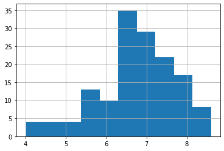

```python
data_set['IMDB'].hist();
```

**07.** Use `.value_counts()` method on `'Fandango_Stars'` column, and see what happens:)

```python
data_set['Fandango_Stars'].value_counts()
```

```
4.5    55
4.0    41
3.5    27
3.0    12
5.0    11
Name: Fandango_Stars, dtype: int64
```

**08.** Use `normalize=True` argument in the `.value_counts()` method on `'Fandango_Stars'` column to obtain ratios of the previous result. Then plot the new result as a pie chart.

```python
new_res = data_set['Fandango_Stars'].value_counts(normalize=True)
new_res
```

```
4.5    0.376712
4.0    0.280822
3.5    0.184932
3.0    0.082192
5.0    0.075342
Name: Fandango_Stars, dtype: float64
```

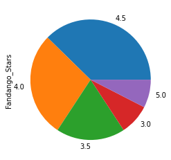

```python
new_res.plot.pie();
```

**09.** Using an appropriate method sort all the movies according to their IMDB ratings. Then, using a proper argument sort them in descending order.

```python
data_set.sort_values(by='IMDB')
```

|  | FILM | RottenTomatoes | Metacritic | IMDB | Fandango_Stars |
| --- | --- | --- | --- | --- | --- |
| 48 | Fantastic Four (2015) | 9 | 27 | 4.0 | 3.0 |
| 97 | Fifty Shades of Grey (2015) | 25 | 46 | 4.2 | 4.0 |
| 133 | Paul Blart: Mall Cop 2 (2015) | 5 | 13 | 4.3 | 3.5 |
| 101 | The Gallows (2015) | 16 | 30 | 4.4 | 3.0 |
| 107 | The Vatican Tapes (2015) | 13 | 37 | 4.6 | 3.0 |
| ... | ... | ... | ... | ... | ... |
| 42 | About Elly (2015) | 97 | 87 | 8.2 | 4.0 |
| 88 | Mad Max: Fury Road (2015) | 97 | 89 | 8.3 | 4.5 |
| 76 | Straight Outta Compton (2015) | 90 | 72 | 8.4 | 5.0 |
| 95 | The Salt of the Earth (2015) | 96 | 83 | 8.4 | 4.5 |
| 140 | Inside Out (2015) | 98 | 94 | 8.6 | 4.5 |

146 rows × 5 columns

```python
data_set.sort_values(by='IMDB', ascending=False)
```

|  | FILM | RottenTomatoes | Metacritic | IMDB | Fandango_Stars |
| --- | --- | --- | --- | --- | --- |
| 140 | Inside Out (2015) | 98 | 94 | 8.6 | 4.5 |
| 76 | Straight Outta Compton (2015) | 90 | 72 | 8.4 | 5.0 |
| 95 | The Salt of the Earth (2015) | 96 | 83 | 8.4 | 4.5 |
| 88 | Mad Max: Fury Road (2015) | 97 | 89 | 8.3 | 4.5 |
| 28 | Wild Tales (2014) | 96 | 77 | 8.2 | 4.5 |
| ... | ... | ... | ... | ... | ... |
| 107 | The Vatican Tapes (2015) | 13 | 37 | 4.6 | 3.0 |
| 101 | The Gallows (2015) | 16 | 30 | 4.4 | 3.0 |
| 133 | Paul Blart: Mall Cop 2 (2015) | 5 | 13 | 4.3 | 3.5 |
| 97 | Fifty Shades of Grey (2015) | 25 | 46 | 4.2 | 4.0 |
| 48 | Fantastic Four (2015) | 9 | 27 | 4.0 | 3.0 |

146 rows × 5 columns

**10.** Select all movies with Rotten Tomatoes rating of 100.

```python
data_set[data_set['RottenTomatoes'] == 100]
```

|  | FILM | RottenTomatoes | Metacritic | IMDB | Fandango_Stars |
| --- | --- | --- | --- | --- | --- |
| 70 | Seymour: An Introduction (2015) | 100 | 83 | 7.7 | 4.5 |
| 144 | Gett: The Trial of Viviane Amsalem (2015) | 100 | 90 | 7.8 | 3.5 |

**11.** Select all movies with Metacritic score lower than 20.

```python
data_set[data_set['Metacritic'] < 20]
```

|  | FILM | RottenTomatoes | Metacritic | IMDB | Fandango_Stars |
| --- | --- | --- | --- | --- | --- |
| 133 | Paul Blart: Mall Cop 2 (2015) | 5 | 13 | 4.3 | 3.5 |

**12.** Select all movies with IMDB rating of 8 or higher.

```python
data_set[data_set['IMDB'] >= 8]
```

|  | FILM | RottenTomatoes | Metacritic | IMDB | Fandango_Stars |
| --- | --- | --- | --- | --- | --- |
| 14 | The Imitation Game (2014) | 90 | 73 | 8.1 | 5.0 |
| 28 | Wild Tales (2014) | 96 | 77 | 8.2 | 4.5 |
| 42 | About Elly (2015) | 97 | 87 | 8.2 | 4.0 |
| 76 | Straight Outta Compton (2015) | 90 | 72 | 8.4 | 5.0 |
| 86 | Me and Earl and The Dying Girl (2015) | 81 | 74 | 8.2 | 4.5 |
| 88 | Mad Max: Fury Road (2015) | 97 | 89 | 8.3 | 4.5 |
| 95 | The Salt of the Earth (2015) | 96 | 83 | 8.4 | 4.5 |
| 96 | Song of the Sea (2014) | 99 | 86 | 8.2 | 4.5 |
| 129 | Amy (2015) | 97 | 85 | 8.0 | 4.5 |
| 140 | Inside Out (2015) | 98 | 94 | 8.6 | 4.5 |

**13.** Using the following logical operators you can combine several logiacl conditions to extract the data based on those conditions:

- ~ NOT
- | OR
- & AND

For example, `data_set[(cond_1) & (cond_2)]` will extract the data meeting both conditions `cond_1` AND `cond_2`. Using these logical operators extract all movies:

- having not more than 3.5 Fandango Stars;
- having Rotten Tomatoes rating either greater than 90 or lower than 10;
- having Rotten Tomatoes score greater than 85, Metacritic score greater than 8.5 and an IMDB score greater than 8.5

```python
data_set[~(data_set['Fandango_Stars'] > 3.5)]
```

|  | FILM | RottenTomatoes | Metacritic | IMDB | Fandango_Stars |
| --- | --- | --- | --- | --- | --- |
| 4 | Hot Tub Time Machine 2 (2015) | 14 | 29 | 5.1 | 3.5 |
| 34 | Aloha (2015) | 19 | 40 | 5.5 | 3.5 |
| 38 | Saint Laurent (2015) | 51 | 52 | 6.3 | 3.5 |
| 39 | Maps to the Stars (2015) | 60 | 67 | 6.3 | 3.5 |
| 48 | Fantastic Four (2015) | 9 | 27 | 4.0 | 3.0 |
| 58 | Seventh Son (2015) | 12 | 30 | 5.5 | 3.5 |
| 59 | Mortdecai (2015) | 12 | 27 | 5.5 | 3.5 |
| 60 | Unfinished Business (2015) | 11 | 32 | 5.4 | 3.5 |
| 62 | True Story (2015) | 45 | 50 | 6.3 | 3.5 |
| 67 | Unfriended (2015) | 60 | 59 | 5.9 | 3.0 |
| 69 | Mr. Turner (2014) | 98 | 94 | 6.9 | 3.5 |
| 79 | Poltergeist (2015) | 31 | 47 | 5.0 | 3.0 |
| 82 | Blackhat (2015) | 34 | 51 | 5.4 | 3.0 |
| 84 | Sinister 2 (2015) | 13 | 31 | 5.5 | 3.5 |
| 87 | Maggie (2015) | 54 | 52 | 5.6 | 3.5 |
| 90 | The SpongeBob Movie: Sponge Out of Water (2015) | 78 | 62 | 6.1 | 3.5 |
| 94 | The Overnight (2015) | 82 | 65 | 6.9 | 3.5 |
| 100 | Jupiter Ascending (2015) | 26 | 40 | 5.5 | 3.5 |
| 101 | The Gallows (2015) | 16 | 30 | 4.4 | 3.0 |
| 103 | Strange Magic (2015) | 17 | 25 | 5.7 | 3.5 |
| 104 | The Gunman (2015) | 17 | 39 | 5.8 | 3.5 |
| 106 | Cake (2015) | 49 | 49 | 6.5 | 3.5 |
| 107 | The Vatican Tapes (2015) | 13 | 37 | 4.6 | 3.0 |
| 111 | Into the Woods (2014) | 71 | 69 | 6.0 | 3.5 |
| 112 | It Follows (2015) | 96 | 83 | 6.9 | 3.0 |
| 113 | Inherent Vice (2014) | 73 | 81 | 6.7 | 3.0 |
| 114 | A Most Violent Year (2014) | 90 | 79 | 7.1 | 3.5 |
| 115 | While We're Young (2015) | 83 | 76 | 6.4 | 3.0 |
| 116 | Clouds of Sils Maria (2015) | 89 | 78 | 6.8 | 3.5 |
| 119 | Phoenix (2015) | 99 | 91 | 7.2 | 3.5 |
| 120 | The Wolfpack (2015) | 84 | 75 | 7.1 | 3.5 |
| 133 | Paul Blart: Mall Cop 2 (2015) | 5 | 13 | 4.3 | 3.5 |
| 135 | The Lazarus Effect (2015) | 14 | 31 | 5.2 | 3.0 |
| 136 | The Woman In Black 2 Angel of Death (2015) | 22 | 42 | 4.9 | 3.0 |
| 139 | Serena (2015) | 18 | 36 | 5.4 | 3.0 |
| 142 | '71 (2015) | 97 | 83 | 7.2 | 3.5 |
| 143 | Two Days, One Night (2014) | 97 | 89 | 7.4 | 3.5 |
| 144 | Gett: The Trial of Viviane Amsalem (2015) | 100 | 90 | 7.8 | 3.5 |
| 145 | Kumiko, The Treasure Hunter (2015) | 87 | 68 | 6.7 | 3.5 |

```python
data_set[(data_set['RottenTomatoes'] > 90) | (data_set['RottenTomatoes'] < 10)]
```

|  | FILM | RottenTomatoes | Metacritic | IMDB | Fandango_Stars |
| --- | --- | --- | --- | --- | --- |
| 8 | Shaun the Sheep Movie (2015) | 99 | 81 | 7.4 | 4.5 |
| 12 | Leviathan (2014) | 99 | 92 | 7.7 | 4.0 |
| 15 | Taken 3 (2015) | 9 | 26 | 6.1 | 4.5 |
| 25 | Selma (2014) | 99 | 89 | 7.5 | 5.0 |
| 26 | Ex Machina (2015) | 92 | 78 | 7.7 | 4.5 |
| 28 | Wild Tales (2014) | 96 | 77 | 8.2 | 4.5 |
| 29 | The End of the Tour (2015) | 92 | 84 | 7.9 | 4.5 |
| 30 | Red Army (2015) | 96 | 82 | 7.7 | 4.5 |
| 32 | The Hunting Ground (2015) | 92 | 77 | 7.5 | 4.5 |
| 40 | I'll See You In My Dreams (2015) | 94 | 75 | 6.9 | 4.0 |
| 41 | Timbuktu (2015) | 99 | 91 | 7.2 | 4.0 |
| 42 | About Elly (2015) | 97 | 87 | 8.2 | 4.0 |
| 43 | The Diary of a Teenage Girl (2015) | 95 | 87 | 7.0 | 4.0 |
| 48 | Fantastic Four (2015) | 9 | 27 | 4.0 | 3.0 |
| 53 | Hot Pursuit (2015) | 8 | 31 | 4.9 | 4.0 |
| 65 | Birdman (2014) | 92 | 88 | 7.9 | 4.0 |
| 66 | The Gift (2015) | 93 | 77 | 7.6 | 4.0 |
| 68 | Monkey Kingdom (2015) | 94 | 72 | 7.3 | 4.5 |
| 69 | Mr. Turner (2014) | 98 | 94 | 6.9 | 3.5 |
| 70 | Seymour: An Introduction (2015) | 100 | 83 | 7.7 | 4.5 |
| 71 | The Wrecking Crew (2015) | 93 | 67 | 7.8 | 4.5 |
| 88 | Mad Max: Fury Road (2015) | 97 | 89 | 8.3 | 4.5 |
| 89 | Spy (2015) | 93 | 75 | 7.3 | 4.5 |
| 91 | Paddington (2015) | 98 | 77 | 7.2 | 4.5 |
| 93 | What We Do in the Shadows (2015) | 96 | 75 | 7.6 | 4.5 |
| 95 | The Salt of the Earth (2015) | 96 | 83 | 8.4 | 4.5 |
| 96 | Song of the Sea (2014) | 99 | 86 | 8.2 | 4.5 |
| 105 | Hitman: Agent 47 (2015) | 7 | 28 | 5.9 | 4.0 |
| 112 | It Follows (2015) | 96 | 83 | 6.9 | 3.0 |
| 119 | Phoenix (2015) | 99 | 91 | 7.2 | 3.5 |
| 122 | Tangerine (2015) | 95 | 86 | 7.4 | 4.0 |
| 128 | Mission: Impossible â€“ Rogue Nation (2015) | 92 | 75 | 7.8 | 4.5 |
| 129 | Amy (2015) | 97 | 85 | 8.0 | 4.5 |
| 133 | Paul Blart: Mall Cop 2 (2015) | 5 | 13 | 4.3 | 3.5 |
| 140 | Inside Out (2015) | 98 | 94 | 8.6 | 4.5 |
| 142 | '71 (2015) | 97 | 83 | 7.2 | 3.5 |
| 143 | Two Days, One Night (2014) | 97 | 89 | 7.4 | 3.5 |
| 144 | Gett: The Trial of Viviane Amsalem (2015) | 100 | 90 | 7.8 | 3.5 |

```python
data_set[(data_set['RottenTomatoes'] > 85) & (data_set['Metacritic'] > 8.5) & (data_set['IMDB'] > 8.5)]
```

|  | FILM | RottenTomatoes | Metacritic | IMDB | Fandango_Stars |
| --- | --- | --- | --- | --- | --- |
| 140 | Inside Out (2015) | 98 | 94 | 8.6 | 4.5 |

**14.** Plot a scatterplot showing the correlation between Metacritic and IMDB scores.

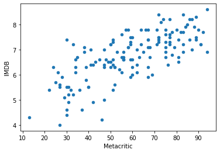

```python
data_set.plot.scatter(x='Metacritic', y='IMDB');
```

```python
data_set = data_set.set_index('FILM')
data_set
```

| FILM | RottenTomatoes | Metacritic | IMDB | Fandango_Stars |
| --- | --- | --- | --- | --- |
| Avengers: Age of Ultron (2015) | 74 | 66 | 7.8 | 5.0 |
| Cinderella (2015) | 85 | 67 | 7.1 | 5.0 |
| Ant-Man (2015) | 80 | 64 | 7.8 | 5.0 |
| Do You Believe? (2015) | 18 | 22 | 5.4 | 5.0 |
| Hot Tub Time Machine 2 (2015) | 14 | 29 | 5.1 | 3.5 |
| ... | ... | ... | ... | ... |
| Mr. Holmes (2015) | 87 | 67 | 7.4 | 4.0 |
| '71 (2015) | 97 | 83 | 7.2 | 3.5 |
| Two Days, One Night (2014) | 97 | 89 | 7.4 | 3.5 |
| Gett: The Trial of Viviane Amsalem (2015) | 100 | 90 | 7.8 | 3.5 |
| Kumiko, The Treasure Hunter (2015) | 87 | 68 | 6.7 | 3.5 |

146 rows × 4 columns

**16.** After setting the index, exctract few rows containing some of your group's favourite movies.

```python
fave_movies = ['Ex Machina (2015)',
              'Birdman (2014)',
              'The Imitation Game (2014)',
              'What We Do in the Shadows (2015)',
              'Inherent Vice (2014)']

data_set.loc[fave_movies]
```

| FILM | RottenTomatoes | Metacritic | IMDB | Fandango_Stars |
| --- | --- | --- | --- | --- |
| Ex Machina (2015) | 92 | 78 | 7.7 | 4.5 |
| Birdman (2014) | 92 | 88 | 7.9 | 4.0 |
| The Imitation Game (2014) | 90 | 73 | 8.1 | 5.0 |
| What We Do in the Shadows (2015) | 96 | 75 | 7.6 | 4.5 |
| Inherent Vice (2014) | 73 | 81 | 6.7 | 3.0 |

DataKolektiv, 2022/23.

hello@datakolektiv.com

[figure not shown]

License: [GPLv3](https://www.gnu.org/licenses/gpl-3.0.txt) This Notebook is free software: you can redistribute it and/or modify it under the terms of the GNU General Public License as published by the Free Software Foundation, either version 3 of the License, or (at your option) any later version. This Notebook is distributed in the hope that it will be useful, but WITHOUT ANY WARRANTY; without even the implied warranty of MERCHANTABILITY or FITNESS FOR A PARTICULAR PURPOSE. See the GNU General Public License for more details. You should have received a copy of the GNU General Public License along with this Notebook. If not, see http://www.gnu.org/licenses/.